# 第16章 多重表

/Users/kazuo/Dropbox/RStudio/CAiP3/CAiP3-chap16.Rmd

fujimoto@sakushin-u.ac.jp

2020年 5月 6日 水曜日 15時26分23秒 JST

- 第16章の前半は、健康自己評価データをつかって、交互作用コーディングを実践している。
- 後半は、このあとの章でも使う「働く女性に対する態度」データが使われる。
- これらは、CARME-n.orgでは、xlsで提供されている（women.xls,women2.xls…women5.xls）。
- これらを生成したもとの生データは、womenraw.xls として提供されているので、ここでは、その生データから、それぞれのxlsに相当するものを生成して検算していく。
- さらに、原文で国と年齢グループと性別を交互作用コーディングしたものがExhibit16.8として提示されているが、これはデータとして提要されていないので、dplyrを使って、この変数をつくり、CAしてみる。
  - 作成は、dplyr
  - グラフ表示では、すべての行ラベルを表示するわけにいかないので、選択的に表示することをやってみた。
  - ラベル座標は、explorをつかって取得し、それをggpltのannote機能で表示。あとは、文字フォントをboldにできればなおよいかも。

# 1 健康評価データに第３の変数を投入する

## 1.1 第6章で使ったデータ（健康データ）の読み込み

```r
.d <- read_excel(path="health.xls")
.d %>% column_to_rownames("...1") -> health.df
.d2 <- read_excel(path="health2.xls")
.d2 %>% column_to_rownames("...1") -> health2.df # health.df を性別で分離したもの
```

## 1.2 Exhibit 6.1 health.df 度数表

```r
health.df %>% as.matrix() %>% addmargins() -> .tbl
.tbl
```

```
##        VG    G    R   B  VB  Sum
## 16-24 243  789  167  18   6 1223
## 25-34 220  809  164  35   6 1234
## 35-44 147  658  181  41   8 1035
## 45-54  90  469  236  50  16  861
## 55-64  53  414  306 106  30  909
## 65-74  44  267  284  98  20  713
## 75+    20  136  157  66  17  396
## Sum   817 3542 1495 414 103 6371
```

## 1.3 Exhibit 6.1 行パーセント

```r
.tbl[,1:5] %>% prop.table(1) -> .tbl2
round(100*.tbl2[,1:5],1)
```

```
##         VG    G    R    B  VB
## 16-24 19.9 64.5 13.7  1.5 0.5
## 25-34 17.8 65.6 13.3  2.8 0.5
## 35-44 14.2 63.6 17.5  4.0 0.8
## 45-54 10.5 54.5 27.4  5.8 1.9
## 55-64  5.8 45.5 33.7 11.7 3.3
## 65-74  6.2 37.4 39.8 13.7 2.8
## 75+    5.1 34.3 39.6 16.7 4.3
## Sum   12.8 55.6 23.5  6.5 1.6
```

# 2 第16章での処理

# 3 Exhibit 16.1 性別集計の行パーセント

```r
bind_rows(health2.df %>% slice(1:7) %>% mutate(gender="male"),
          health2.df %>% slice(8:14) %>% mutate(gender="female")) %>% group_by(gender) %>% summarize_all(.funs=sum) %>% mutate(Total=VG+G+Re+B+VB) -> sumGender

health2.df %>% summarise_all(.funs = sum) %>% mutate(Total=VG+G+Re+B+VB,gender="Sum") -> sumAll

bind_rows(sumGender,sumAll) -> .tbl
.tbl[c(2,1,3),] %>% mutate(VGp=round(100*VG/Total,1),
                           Gp=round(100*G/Total,1),
                           Rep=round(100*Re/Total,1),
                           Bp=round(100*B/Total,1),
                           VBp=round(100*VB/Total,1))
```

```
## # A tibble: 3 x 12
##   gender    VG     G    Re     B    VB Total   VGp    Gp   Rep    Bp   VBp
##   <chr>  <dbl> <dbl> <dbl> <dbl> <dbl> <dbl> <dbl> <dbl> <dbl> <dbl> <dbl>
## 1 male     448  1789   636   177    39  3089  14.5  57.9  20.6   5.7   1.3
## 2 female   369  1753   859   237    64  3282  11.2  53.4  26.2   7.2   2
## 3 Sum      817  3542  1495   414   103  6371  12.8  55.6  23.5   6.5   1.6
```

## Exhibit 16.2 交互作用コーディング（性別×年齢）

```r
base_row <- rownames(health.df)
#health2.df
#oldrow <- rownames(health2.df)
#newrow <- c(str_c(rep("m",7),base_row),str_c(rep("f",7),base_row))
rownames(health2.df) <- c(str_c(rep("m",7),base_row),str_c(rep("f",7),base_row))
health2.df %>% mutate(Sum=VG+G+Re+B+VB,rname=rownames(health2.df)) %>% column_to_rownames("rname") -> health2a.df
knitr::kable(health2a.df)
```

|  | VG | G | Re | B | VB | Sum |
| --- | --- | --- | --- | --- | --- | --- |
| m16-24 | 145 | 402 | 84 | 5 | 3 | 639 |
| m25-34 | 112 | 414 | 74 | 13 | 2 | 615 |
| m35-44 | 80 | 331 | 82 | 24 | 4 | 521 |
| m45-54 | 54 | 231 | 102 | 22 | 6 | 415 |
| m55-64 | 30 | 219 | 119 | 53 | 12 | 433 |
| m65-74 | 18 | 125 | 110 | 35 | 4 | 292 |
| m75+ | 9 | 67 | 65 | 25 | 8 | 174 |
| f16-24 | 98 | 387 | 83 | 13 | 3 | 584 |
| f25-34 | 108 | 395 | 90 | 22 | 4 | 619 |
| f35-44 | 67 | 327 | 99 | 17 | 4 | 514 |
| f45-54 | 36 | 238 | 134 | 28 | 10 | 446 |
| f55-64 | 23 | 195 | 187 | 53 | 18 | 476 |
| f65-74 | 26 | 142 | 174 | 63 | 16 | 421 |
| f75+ | 11 | 69 | 92 | 41 | 9 | 222 |

## 3.1 Exhibit 16.3 (FactoMiner::plot.CA) 交互作用コーディングした表へのCA

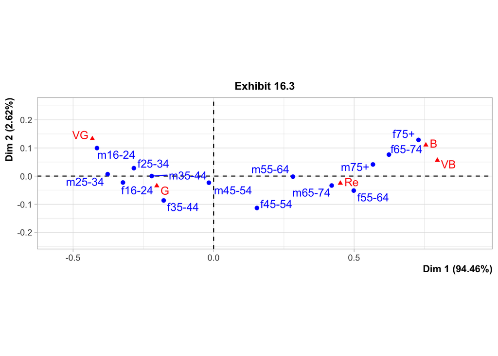

```r
res.CA <- CA(health2a.df[,1:5],graph=FALSE)
plot.CA(res.CA,title = "Exhibit 16.3")
```

## 3.2 Exhibit 16.3 (fviz_ca_biplot 版)

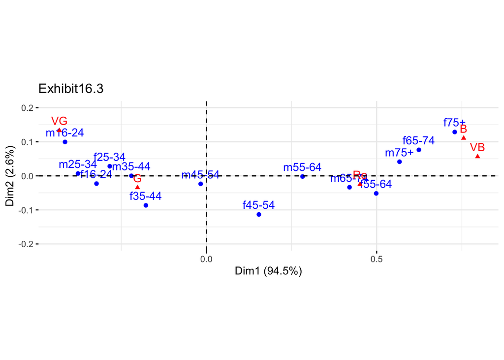

```r
p <- fviz_ca_biplot(res.CA)
p <- p + coord_fixed(ratio = 1)
p <- p + ggtitle("Exhibit16.3") + ylim(-0.2,0.2)
p
```

## 3.3 破線で繋ぐための座標を取得

```r
res.CA$row$coord[,1:2] -> r_coord
```

## 3.4 性別で性別・年齢ポイントを繋ぐ

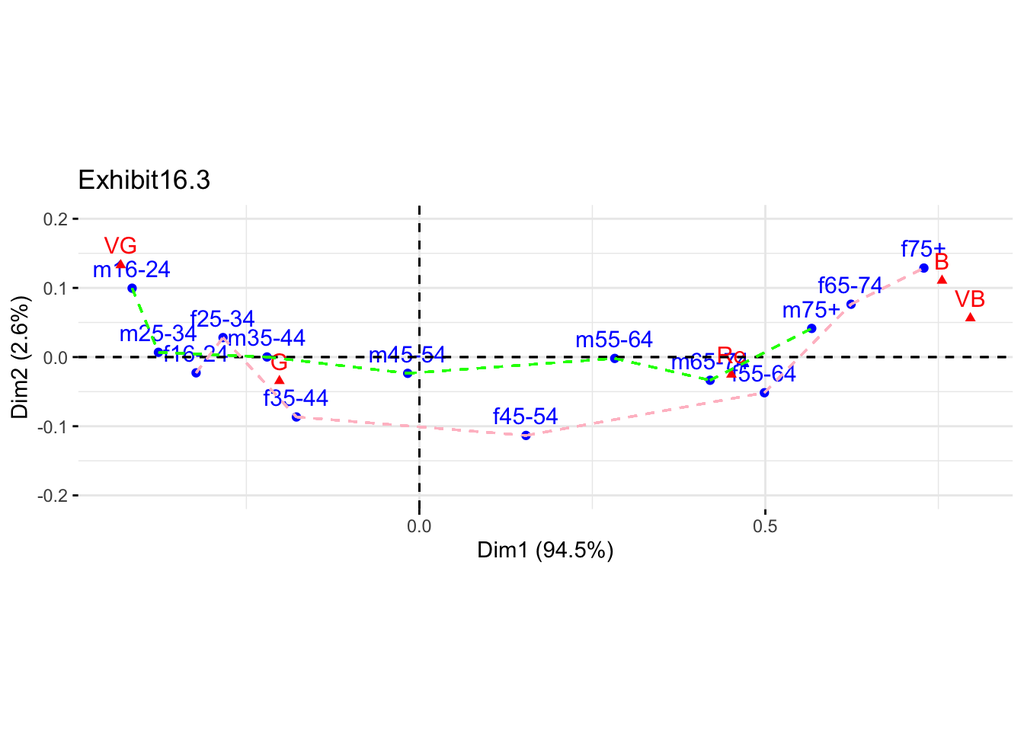

```r
### geom_segment をつかって、ポイント間をつないでいる。もっとスマートにできないだろうか。

r_coord[1:7,] -> r_coord_m # 男性
r_coord[8:14,] -> r_coord_f#女性

bind_rows(r_coord %>% tbl_df %>% slice(1:7) %>% mutate(Gender="male"),
         r_coord %>% tbl_df %>% slice(8:14) %>% mutate(Gender="female")) -> r_coord_list

p <- fviz_ca_biplot(res.CA)
p <- p + coord_fixed(ratio = 1)
p <- p + ggtitle("Exhibit16.3") + ylim(-0.2,0.2)
for(i in 1:6){　# 男性
  p <- p + geom_segment(x=r_coord[i,1],xend=r_coord[i+1,1],y=r_coord[i,2],yend=r_coord[i+1,2],colour = "green",linetype="dashed")
}
for(i in 8:13){ # 女性
  p <- p + geom_segment(x=r_coord[i,1],xend=r_coord[i+1,1],y=r_coord[i,2],yend=r_coord[i+1,2],colour = "pink",linetype="dashed")
}
p
```

## 3.5 年齢グループごとの男性間、女性間 をつなぐ

```r
rcoodxy <- list()
for(i in 1:7){
  r_coord[c(i,i+7),] -> rcoodxy[[i]]
}
rcoodxy[[1]][1,]# start
```

```
##       Dim 1       Dim 2
## -0.41507250  0.09957115
```

```r
rcoodxy[[1]][2,]# stop
```

```
##       Dim 1       Dim 2
## -0.32264532 -0.02280258
```

# 4 生データ(womenraw.xls)から各women*.xlsをつくってみる

- Exhibit 16.4 〜16.8用にxlsが用意されているが、ここではあえて、生データからそれらをつくりだしてみる。
- このwomenraw.xlsは、SPSSのsavファイルからつくりだすこともできる。

## 4.1 womenraw.xls を読み込む

```r
.d <- read_excel(path="womenraw.xls")
.d %>% mutate(Q1 = factor(Q1),Q2 = factor(Q2),Q3 = factor(Q3),Q4 = factor(Q4),
              C = factor(C),G= factor(G),A=factor(A),M=factor(M),E=factor(E)) -> .d.f
nrow(.d.f)
```

```
## [1] 33590
```

```r
.d.f %>% summary()
```

```
##  Q1        Q2        Q3        Q4              C         G         A
##  1:24238   1: 3009   1: 7271   1:21540   24     : 2494   1:15230   1:5001
##  2: 4908   2:11986   2:17774   2: 6479   2      : 2324   2:18323   2:6959
##  3: 2062   3:16180   3: 5960   3: 2077   12     : 2087   9:   37   3:6958
##  4: 2382   4: 2415   4: 2585   4: 3494   18     : 1998             4:5504
##                                          11     : 1968             5:4530
##                                          1      : 1779             6:4638
##                                          (Other):20940
##  M               E
##  1:21589   5      :8717
##  2: 2540   3      :6765
##  3: 1744   4      :6485
##  4:  424   6      :3873
##  5: 7184   7      :3676
##  9:  109   0      :2494
##            (Other):1580
```

```r
.d.f %>% head()
```

```
## # A tibble: 6 x 9
##   Q1    Q2    Q3    Q4    C     G     A     M     E
##   <fct> <fct> <fct> <fct> <fct> <fct> <fct> <fct> <fct>
## 1 1     3     2     2     1     2     6     1     3
## 2 1     2     2     2     1     2     4     1     4
## 3 1     3     4     4     1     2     1     5     7
## 4 1     2     2     1     1     2     4     1     4
## 5 1     3     2     4     1     1     5     1     4
## 6 1     2     1     1     1     2     1     5     5
```

## 4.2 カテゴリのラベル化

- ISSP1994 の調査の日本での調査票

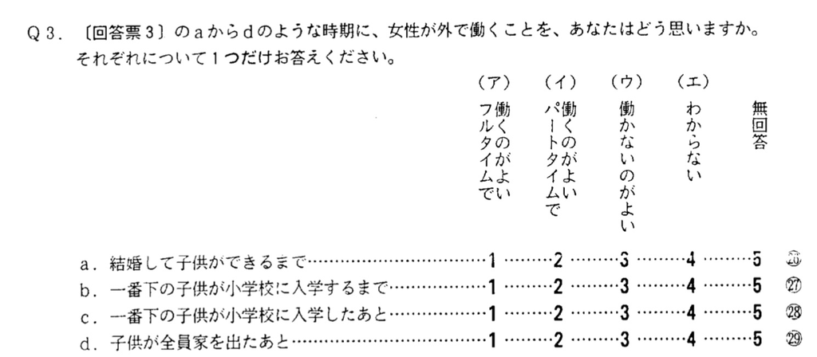

```r
#.d.f %>% count(C)
name_tbl_Q <- setNames(c("W","w","H","?"),1:4)
name_tbl_C <- setNames(c("AUS","DW","DE","GB","NIRL","USA","A","H","I","IRL","NL","N","S","CZ",
                          "SLO","PL","BG","RUS","NZ","CDN","RP","IL","J","E"),1:24)

name_tbl_G <- setNames(c("m","f"),1:2)
name_tbl_A <- setNames(c("<25","26-35","36-45","46-55","56-65",">66"),1:6)
name_tbl_M <- setNames(c("ma","wi","di","se","si",NA),c(1:5,9))
name_tbl_E <- setNames(c(NA,"E1","E2","E3","E4","E5","E6","E7","DK",NA),c(0:7,98,99))


.d.f %>% mutate(Q1 = recode(Q1,!!!name_tbl_Q),Q2 = recode(Q2,!!!name_tbl_Q),
                Q3 = recode(Q3,!!!name_tbl_Q),Q4 = recode(Q4,!!!name_tbl_Q),
                C = recode(C,!!!name_tbl_C),# 国
                G = recode(G,!!!name_tbl_G),# 性別
                A = recode(A,!!!name_tbl_A),# 年齢
                M = recode(M,!!!name_tbl_M),# 婚姻状態　-- 17章で使う
                E = recode(E,!!!name_tbl_E) # 学歴　　　-- 17章で使う
                ) -> .d.conv
.d.conv %>% summary(maxsum=24)
```

```
##  Q1        Q2        Q3        Q4           C        G             A
##  W:24238   W: 3009   W: 7271   W:21540   AUS :1779   m:15230   <25  :5001
##  w: 4908   w:11986   w:17774   w: 6479   DW  :2324   f:18323   26-35:6959
##  H: 2062   H:16180   H: 5960   H: 2077   DE  :1097   9:   37   36-45:6958
##  ?: 2382   ?: 2415   ?: 2585   ?: 3494   GB  : 984             46-55:5504
##                                          NIRL: 647             56-65:4530
##                                          USA :1447             >66  :4638
##                                          A   : 977
##                                          H   :1500
##                                          I   :1018
##                                          IRL : 938
##                                          NL  :1968
##                                          N   :2087
##                                          S   :1272
##                                          CZ  :1024
##                                          SLO :1032
##                                          PL  :1597
##                                          BG  :1126
##                                          RUS :1998
##                                          NZ  :1047
##                                          CDN :1440
##                                          RP  :1200
##                                          IL  :1287
##                                          J   :1307
##                                          E   :2494
##     M            E
##  ma  :21589   E1  : 285
##  wi  : 2540   E2  :1109
##  di  : 1744   E3  :6765
##  se  :  424   E4  :6485
##  si  : 7184   E5  :8717
##  NA's:  109   E6  :3873
##               E7  :3676
##               DK  :   1
##               NA's:2679
##
##
##
##
##
##
##
##
##
##
##
##
##
##
##
```

```r
#.d.conv %>% count(C) # check 用
```

## 4.3 Exhibit 16.4 行：国、列Q3によるクロス集計

```r
.d.conv %>% xtabs(~C+Q3,.) -> .tbl16.3
.tbl16.3 %>% addmargins()
```

```
##       Q3
## C          W     w     H     ?   Sum
##   AUS    256  1156   176   191  1779
##   DW     101  1394   581   248  2324
##   DE     278   691    62    66  1097
##   GB     161   646    70   107   984
##   NIRL   126   394    75    52   647
##   USA    482   686   107   172  1447
##   A       84   632   202    59   977
##   H      285   736   447    32  1500
##   I      171   670   167    10  1018
##   IRL    223   424   209    82   938
##   NL     539  1205   143    81  1968
##   N      487  1242   205   153  2087
##   S      295   833    39   105  1272
##   CZ     228   585   198    13  1024
##   SLO    341   428   222    41  1032
##   PL     431   425   589   152  1597
##   BG     270   427   335    94  1126
##   RUS    175  1154   550   119  1998
##   NZ     120   754    72   101  1047
##   CDN    566   497   108   269  1440
##   RP     243   448   484    25  1200
##   IL     468   664    92    63  1287
##   J      203   671   313   120  1307
##   E      738  1012   514   230  2494
##   Sum   7271 17774  5960  2585 33590
```

## 4.4 Exhibit 16.5

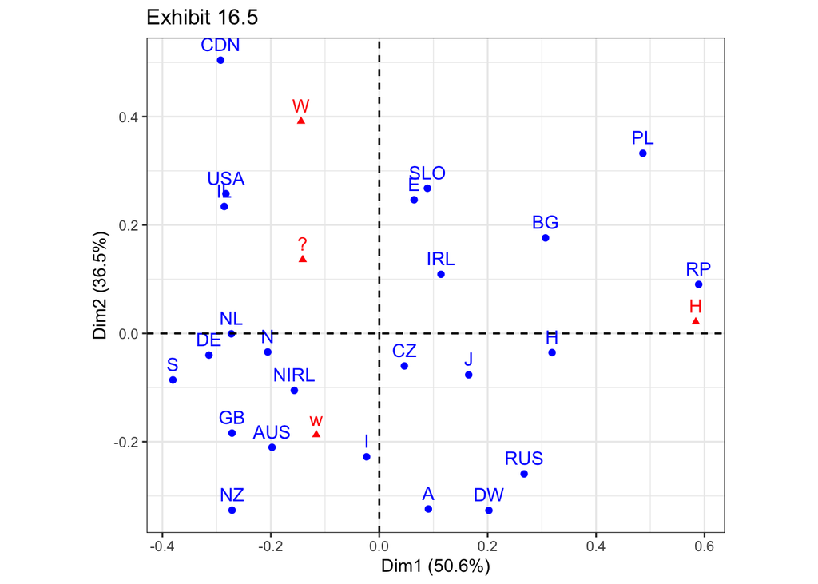

```r
res.CA <- CA(.tbl16.3,graph = FALSE)
fviz_ca_biplot(res.CA) + coord_fixed(ratio = 1) + ggtitle("Exhibit 16.5") + theme_bw()
```

# 5 交互作用変数を合成しクロス集計を行いCAを行う。Exhibit 16.6、16.7,16.8

```r
# 表で、国・性別をならべる順序をfactorのlevelsで指定しておく。
outer(name_tbl_C,c("m","f"),paste0) -> .tmp
ll <- NULL
for(i in 1:24){
  ll <- append(ll,.tmp[i,])
}
cg_levels <- ll

#.d.conv %>% mutate(CG=str_c(C,G),CGA=str_c(C,G,A)) -> .d.conv2
.d.conv %>%  count(C,G,Q3) %>% mutate(CG=factor(str_c(C,G),levels = cg_levels)) %>%
                                         filter(G!=9) %>% select(CG,Q3,n) %>%
                                         spread(key=Q3,value = n) %>% # xtabs でやっていること
                                         mutate(Total=(W+w+H+`?`)) %>%
                                         mutate(Wp=round(100*W/Total,1),wp=round(100*w/Total,1),
                                                Hp=round(100*H/Total,1),
                                                `?p`=round(100*`?`/Total,1)) %>%
                                         select(CG,Wp,wp,Hp,`?p`,Total)
```

```
## # A tibble: 48 x 6
##    CG       Wp    wp    Hp  `?p` Total
##    <fct> <dbl> <dbl> <dbl> <dbl> <int>
##  1 AUSm   12.9  65.6  12.5   9     909
##  2 AUSf   15.9  64.5   6.9  12.6   866
##  3 DWm     3.6  56.3  29.8  10.3  1198
##  4 DWf     5.2  63.9  19.9  11.1  1126
##  5 DEm    27.7  59.8   5.5   7     528
##  6 DEf    23.2  65.9   5.8   5.1   569
##  7 GBm    17.9  64.1   7.8  10.3   448
##  8 GBf    15.1  67     6.5  11.4   536
##  9 NIRLm  20.7  56.7  14.4   8.2   305
## 10 NIRLf  18.4  64.6   9.1   7.9   342
## # … with 38 more rows
```

### 5.0.1 CG を正しくfactor化しておけば、xtabsでもその順序で表示される。

- 入力にtable属性を必要とする場合は、xtabsを使えばいいかも。
- tbl_df からtable属性への変更ができれば、その方がスマート

```r
.d.conv %>%  count(C,G,Q3) %>% mutate(CG=factor(str_c(C,G),levels = cg_levels)) %>%
                                         filter(G!=9) %>% select(CG,Q3,n) %>% xtabs(n~CG+Q3,.)
```

```
##        Q3
## CG        W   w   H   ?
##   AUSm  117 596 114  82
##   AUSf  138 559  60 109
##   DWm    43 675 357 123
##   DWf    58 719 224 125
##   DEm   146 316  29  37
##   DEf   132 375  33  29
##   GBm    80 287  35  46
##   GBf    81 359  35  61
##   NIRLm  63 173  44  25
##   NIRLf  63 221  31  27
##   USAm  185 284  56  71
##   USAf  297 402  51 101
##   Am     36 270  98  29
##   Af     48 362 104  30
##   Hm    114 302 206  13
##   Hf    171 434 241  19
##   Im     81 300 110   7
##   If     90 370  57   3
##   IRLm  106 177 124  45
##   IRLf  117 247  85  37
##   NLm   230 523  90  38
##   NLf   309 682  53  43
##   Nm    229 531 119  67
##   Nf    258 711  86  86
##   Sm    158 372  19  48
##   Sf    137 461  20  57
##   CZm   121 271 103   8
##   CZf   107 314  95   5
##   SLOm  152 191 108  26
##   SLOf  189 237 114  15
##   PLm   179 176 292  78
##   PLf   252 249 297  74
##   BGm   113 163 128  48
##   BGf   157 263 207  46
##   RUSm   70 377 204  75
##   RUSf  105 777 346  44
##   NZm    45 305  29  39
##   NZf    73 433  42  59
##   CDNm  199 185  57  92
##   CDNf  366 312  51 176
##   RPm   114 202 269  15
##   RPf   129 246 215  10
##   ILm   220 275  57  29
##   ILf   247 387  35  34
##   Jm     85 279 171  57
##   Jf    118 392 142  63
##   Em    347 445 294 111
##   Ef    390 566 218 118
```

## 5.1 Exhibit 16.6 交互作用変数CG（国・性別）× Q3のクロス集計

- xtabs version

```r
.d.conv %>% filter(G!=9) %>% mutate(CG=factor(str_c(C,G),levels = cg_levels)) %>%
  xtabs(~ CG + Q3,.) %>% prop.table(1) -> .tbl
round(.tbl*100,1)
```

```
##        Q3
## CG         W    w    H    ?
##   AUSm  12.9 65.6 12.5  9.0
##   AUSf  15.9 64.5  6.9 12.6
##   DWm    3.6 56.3 29.8 10.3
##   DWf    5.2 63.9 19.9 11.1
##   DEm   27.7 59.8  5.5  7.0
##   DEf   23.2 65.9  5.8  5.1
##   GBm   17.9 64.1  7.8 10.3
##   GBf   15.1 67.0  6.5 11.4
##   NIRLm 20.7 56.7 14.4  8.2
##   NIRLf 18.4 64.6  9.1  7.9
##   USAm  31.0 47.7  9.4 11.9
##   USAf  34.9 47.2  6.0 11.9
##   Am     8.3 62.4 22.6  6.7
##   Af     8.8 66.5 19.1  5.5
##   Hm    18.0 47.6 32.4  2.0
##   Hf    19.8 50.2 27.9  2.2
##   Im    16.3 60.2 22.1  1.4
##   If    17.3 71.2 11.0  0.6
##   IRLm  23.5 39.2 27.4 10.0
##   IRLf  24.1 50.8 17.5  7.6
##   NLm   26.1 59.4 10.2  4.3
##   NLf   28.4 62.7  4.9  4.0
##   Nm    24.2 56.1 12.6  7.1
##   Nf    22.6 62.3  7.5  7.5
##   Sm    26.5 62.3  3.2  8.0
##   Sf    20.3 68.3  3.0  8.4
##   CZm   24.1 53.9 20.5  1.6
##   CZf   20.5 60.3 18.2  1.0
##   SLOm  31.9 40.0 22.6  5.5
##   SLOf  34.1 42.7 20.5  2.7
##   PLm   24.7 24.3 40.3 10.8
##   PLf   28.9 28.6 34.1  8.5
##   BGm   25.0 36.1 28.3 10.6
##   BGf   23.3 39.1 30.8  6.8
##   RUSm   9.6 51.9 28.1 10.3
##   RUSf   8.3 61.1 27.2  3.5
##   NZm   10.8 73.0  6.9  9.3
##   NZf   12.0 71.3  6.9  9.7
##   CDNm  37.3 34.7 10.7 17.3
##   CDNf  40.4 34.5  5.6 19.4
##   RPm   19.0 33.7 44.8  2.5
##   RPf   21.5 41.0 35.8  1.7
##   ILm   37.9 47.3  9.8  5.0
##   ILf   35.1 55.0  5.0  4.8
##   Jm    14.4 47.1 28.9  9.6
##   Jf    16.5 54.8 19.9  8.8
##   Em    29.0 37.2 24.6  9.3
##   Ef    30.2 43.8 16.9  9.1
```

- xtabs + prop.table をdplyr だけでやって、それをtable属性に変換する！（これで、table属性を必要とするfunctionにわたすのに、xtabsを使わなくもOKになる！）

```r
.d.conv %>%  count(C,G,Q3) %>% mutate(CG=factor(str_c(C,G),levels = cg_levels)) %>%
                                         filter(G!=9) %>% select(CG,Q3,n) %>%
                                         spread(key=Q3,value = n) %>%
  column_to_rownames("CG") %>% as.matrix() %>% as.table()
```

```
##         W   w   H   ?
## AUSm  117 596 114  82
## AUSf  138 559  60 109
## DWm    43 675 357 123
## DWf    58 719 224 125
## DEm   146 316  29  37
## DEf   132 375  33  29
## GBm    80 287  35  46
## GBf    81 359  35  61
## NIRLm  63 173  44  25
## NIRLf  63 221  31  27
## USAm  185 284  56  71
## USAf  297 402  51 101
## Am     36 270  98  29
## Af     48 362 104  30
## Hm    114 302 206  13
## Hf    171 434 241  19
## Im     81 300 110   7
## If     90 370  57   3
## IRLm  106 177 124  45
## IRLf  117 247  85  37
## NLm   230 523  90  38
## NLf   309 682  53  43
## Nm    229 531 119  67
## Nf    258 711  86  86
## Sm    158 372  19  48
## Sf    137 461  20  57
## CZm   121 271 103   8
## CZf   107 314  95   5
## SLOm  152 191 108  26
## SLOf  189 237 114  15
## PLm   179 176 292  78
## PLf   252 249 297  74
## BGm   113 163 128  48
## BGf   157 263 207  46
## RUSm   70 377 204  75
## RUSf  105 777 346  44
## NZm    45 305  29  39
## NZf    73 433  42  59
## CDNm  199 185  57  92
## CDNf  366 312  51 176
## RPm   114 202 269  15
## RPf   129 246 215  10
## ILm   220 275  57  29
## ILf   247 387  35  34
## Jm     85 279 171  57
## Jf    118 392 142  63
## Em    347 445 294 111
## Ef    390 566 218 118
```

## 5.2 Exhinit 16.7

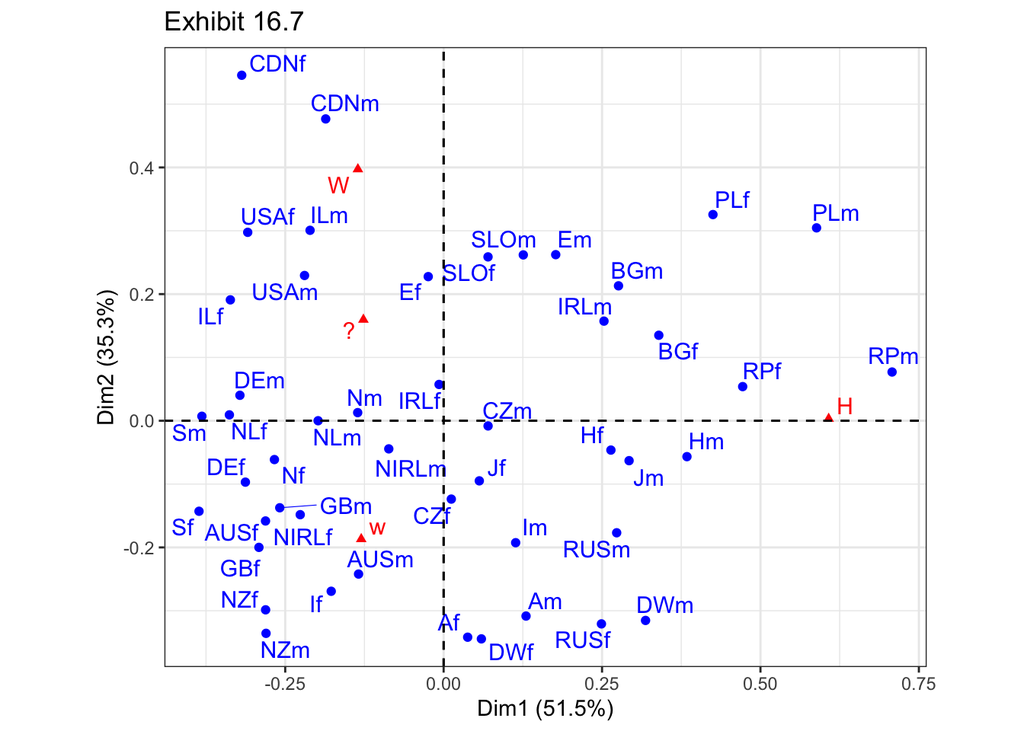

```r
#.d.conv2 %>% filter(G!=9) %>% xtabs(~ CG + Q3,.)
.d.conv %>% filter(G!=9) %>% mutate(CG=factor(str_c(C,G),levels = cg_levels))　%>% xtabs(~ CG + Q3,.) %>% FactoMineR::CA(graph = FALSE) -> res.CA
#plot(res.CA,repel=TRUE)
fviz_ca_biplot(res.CA,repel = TRUE) + coord_fixed(ratio = 1) + theme_bw() + ggtitle("Exhibit 16.7")
```

## 5.3 Exhibit 16.8

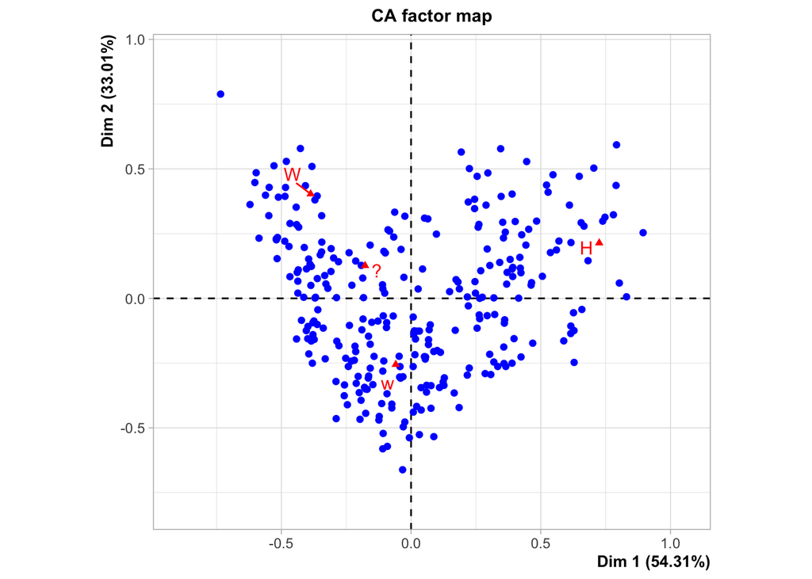

```r
#.d.conv2 %>% filter(G!=9) %>%
.d.conv %>% filter(G!=9) %>% mutate(CGA=factor(str_c(C,G,A)))　%>%
  xtabs(~ CGA + Q3,.) %>% FactoMineR::CA(graph = FALSE) -> res.CA
plot(res.CA,label = "col")
```

## 5.4 選択的ラベル表示

```r
explor(res.CA)
###　explor_var_labels.csv
res <- explor::prepare_results(res.CA)
explor::CA_var_plot(res, xax = 1, yax = 2, var_sup = FALSE, var_hide = "None",
    var_lab_min_contrib = 2, col_var = "Position", symbol_var = NULL, size_var = NULL,
    size_range = c(10, 300), labels_size = 10, point_size = 12, transitions = TRUE,
    labels_positions = NULL, xlim = c(-1.08, 1.28), ylim = c(-1.08, 1.28))
```

```r
lable.pos <- read_csv("explor_var_labels_all.csv") # これは、explorであらかじめ取得しておく。
lable.pos %>% filter(TAG=="OK") %>% slice(-c(1:4)) -> label.xy
# この値、ｘは、res.CA$row$coord のDim1と同じであるが、yは、＋にあるときは、Dim2よる少し大きく（つまりPointの上）、ーにあるときは、Dim2より少し小さく（これもポイントの上）なるように、設定されている。これが文字位置ということなのだろう。係数を計算しておこう。

label.xy[1,] -> CDNf25
CDNf25$lab_x
```

```
## [1] -0.734
```

```r
CDNf25$lab_y
```

```
## [1] 0.8312373
```

```r
CDNf25$lab
```

```
## [1] "CDNf<25"
```

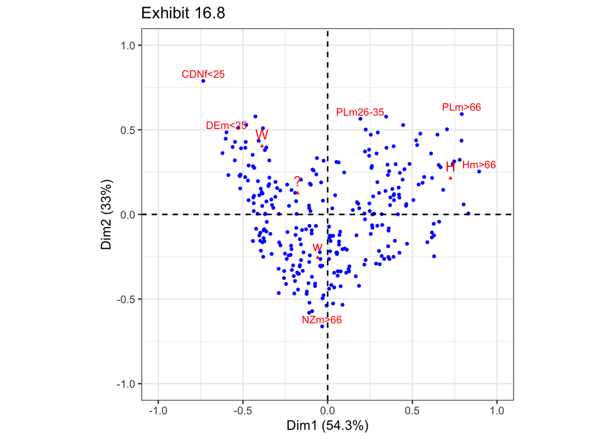

```r
p <- fviz_ca_biplot(res.CA,label="col",pointsize = 0.8,title = "Exhibit 16.8") +
  coord_fixed(ratio = 1) + xlim(-1,1) + ylim(-1,1) + theme_bw()
#p <- p  + annotate("text", x=CDNf25$lab_x,y=CDNf25$lab_y,label=CDNf25$lab,colour="red",size=3)
p <- p  + annotate("text", x=label.xy$lab_x,y=label.xy$lab_y,label=label.xy$lab,colour="red",size=3)
p
```

## 5.5 chap17 スペインの学歴（E）がNA？ 0 であることの確認

```r
.d.conv %>% filter(C == "E")
```

```
## # A tibble: 2,494 x 9
##    Q1    Q2    Q3    Q4    C     G     A     M     E
##    <fct> <fct> <fct> <fct> <fct> <fct> <fct> <fct> <fct>
##  1 W     H     W     W     E     m     56-65 ma    <NA>
##  2 W     ?     W     W     E     f     26-35 se    <NA>
##  3 W     ?     W     W     E     f     36-45 ma    <NA>
##  4 W     H     W     W     E     f     26-35 ma    <NA>
##  5 ?     ?     ?     ?     E     m     <25   si    <NA>
##  6 ?     ?     ?     ?     E     f     >66   wi    <NA>
##  7 H     H     H     H     E     f     46-55 ma    <NA>
##  8 H     H     H     H     E     f     >66   ma    <NA>
##  9 W     w     W     W     E     m     <25   si    <NA>
## 10 H     H     H     H     E     f     56-65 wi    <NA>
## # … with 2,484 more rows
```